# Facility Visits: Bataan Free-Port Zone

Anieta, Anne Lorrraine C. , Ong, Christine Kaye B.

12/8/2017

Guang Qiang Manufacturing Corporation

The first company that we had visited was Guang Qiang Manufacturing Corporation. It is a manufacturing company that produces metal molds for bags. They mostly supply their products to international brands like Coach, Kate Spade, Michael Kors, and other famous international brands. They had also supplied to Louis Vuitton. They have been in the Free Port Area of Bataan for two and a half years already. They have their main company in China for twenty years already. They were able to establish the company in the Philippines because of the demand of bag manufacturers in the Philippines.

When we visited there were not that many order from them so they were able to entertain us, as they were not that busy. The factory building was not that big. The appearance of the factory was not organized. There were piles of stock materials at the entrance. There were only a few workers and they do not have uniforms. The workers do not have safety equipment with them as they do some processes that requires that. The head manager in the factory were Chinese nationals. When we asked the workers, they were like they really do not know the overall process of the production. They were just taught on what to do and they just follow it. They were given a pattern to follow.

Value Chain

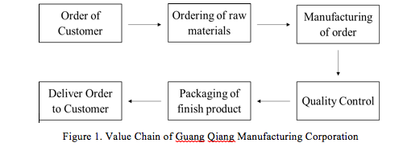

Process

The customers place their order from them. Then they order the materials needed to manufacture the order of the customer from the supplier. Then they manufacture the order of the customer as to their specification. Then they check if the quality of the finished product is up to standards. After the order of the customer is finished, it will be packed and will be ready to be delivered to the customer.

Processes

The production process for the metal mold starts with the pattern making process. Someone makes the pattern to be followed by the metal mold. Their employee makes the pattern in a computer with the exact measures so that when it is inputted in the machine it will work precisely. There is a machine called the CNC Machine, wherein the pattern of the mold is inputted, the machine will follow the shape of the pattern and cut the mold according to it, and it will be done.

There is also another process to make other metal molds. The first process is the measuring of the metal to be used for the mold. Then next is the bending process, where the metal is formed. It is shaped according to the pattern that they need to follow. Then the bended metal will be welded repeatedly until it is good. Welding process is done to join the metal together. This is the finishing part, where the mold is processed until it is in accordance with the pattern that was given to them. After that, they will paint the metal mold and put markings on it. The final output is ready to be delivered. There is also the lamination section, where the fabrics are laminated. There are two kinds of fabrics, the cordura and the foam. They attach these two fabrics together because other company requests it.

They distribute their products to bag manufacturing companies in the Free Port Area of Bataan like the one we visited the FCF Manufacturing Company and FPF Corporation.

Process Flowchart

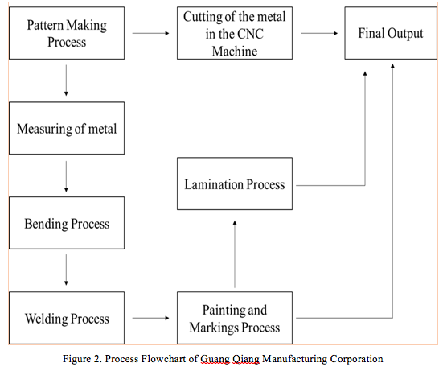

Process

Equipment

The factory was not that big in space but there were many equipment and machineries that we saw. Some of those machines were the bending machine, welding machine and the CNC machine. A bending machine is a forming machine tool. Its purpose is to make a bend on a work piece. A bend is formed by using a bending tool during a linear or rotating move (Wikipedia, June 13, 2017). A welding machine is an equipment, which connects two metals or thermoplastics by heat. It helps to unite or fuse by hammering (Cano, March 16). The CNC machine comprises of the computer in which the program is supplied for cutting of the metal of the job as per the requirements (Khemani, November 13, 2009). It was a big machine that cuts the metal according to the pattern inputted in the computer. Once the metal undergoes through this machine, it will be the final product.

They have maintenance for their machines and equipment every day.

Human Capital Requirements

For the workers, they do not need to have certain qualifications because they can be trained for the work. However, for the office workers and skilled workers, they need to have background about the type of work they are going to do in the company. They prefer workers with work experiences. Even though, their qualifications for labor is not that detailed, they screen the ones who applied for the certain job. When there is a problem in production, the supervisor will be the one who will bear the responsibility. The manager might fire them and the workers will be reprimanded. The working environment in the factory was not good. The workers were not fully equipped with safety gears. The welders does not have something that would protect their eyes from the spark that welding produces. One employee had a sunglass as protection, but he does not use it. The head manager there was a foreigner, a Chinese national. They have a hard time communicating with their workers, as some of them does not speak English. The workers does not really know what the processes are. They are just taught on what to do and they just follow it. Most of the workers were men as the manufacturing company mostly have hard labor in their processes. The workers did not seem happy in their work.

Medtecs International Corporation Limited

Medtecs International Corporation Limited (MICL) is an incorporated healthcare product and services provider in Asia Pacific, and a leading producer and supplier of medical consumables for the worldwide healthcare industry. They were already in the Philippines since 1989. Over the years, they have established a strong presence in other countries like the United States, Europe, and the Asia Pacific region. At present, the Group has headquarters in Singapore, Hong Kong, Taiwan, the Philippines, Cambodia and People’s Republic of China. The company is an original product manufacturer (OPM) of a broad variety of medical consumables for big international healthcare suppliers, pharmaceutical corporations and hospital groups in the United States and Europe. The main product groups produced include linen, hospital apparel and bandages. (https://medtecs-ph.com/About-Us/). The products that they produce are medical consumables, hospital linens, Barcelona linens, uniforms, and textiles (https://medtecs-ph.com/Products/).

This is the second company that we had visited. At first, we thought that the company is a manufacturer of medical consumables but it was not. It has a wide space of factory plant. They have separate building factory for each department of their production. They have three departments, the weaving, dyeing, and garments department. We first went to the dyeing department, we were able to see the process on what they do in that department. Then we went to the weaving department. It was a little bit farther from the dyeing department. We saw many threads displayed there. Unfortunately, we were not able to visit the garments department because of lack of time. The company produces a lot of units of cloth per day. The cloths that we saw were so many.

Value Chain

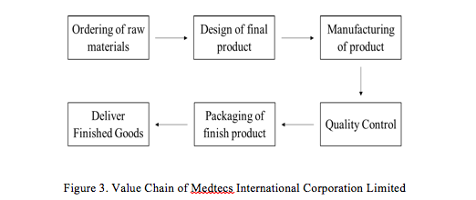

Process

They first order the raw materials that they need for production. Then next, they make the designs of what the final product would look like. Then they start to manufacture the product. Once the product is manufactured, it is checked to see if it is in line with the quality standards. If it is up to standards, it will then be packaged and be ready for delivery.

Processes

There are three main departments which is the weaving, dyeing, and garments department. In the weaving department, the first process is warping. This is where the thread runs up and down in a loom. Then it will be rolled in a big cylinder. Then next is the reeding process. This is where the threads are combed manually by a person to set apart the warped thread evenly. After that it goes through the weaving process, where the thread will be weaved in the machine. Weaving is a process in which sets of yarns or threads are intertwined at accurate angles to produce a fabric or cloth.

In the dyeing department, the first process is the spreading process. This is where they spread the cloth to get the right measurement of the cloth. Then the cloth goes to the overflow section, where the cloth is dyed. Dyeing is the method of putting color to textile products like fibers, yarns, and fabrics. There are many units of machine for this. Each machine has a different color of dye. There is also the jigsaw section for the cotton cloth to be dyed. After that, the dyed cloth goes to the spin dryer section, where it is squeezed to remove the water from the cloth. Then it goes to the scutcher section, where the cloth is spreaded. Then it will go to the drying section, where the cloth is dried in a long machine. Then it goes to the pitching section, where the cloth is smoothen.

In the garments department, the final good is created. This is where they make the final products like linens, textiles, uniforms, and other cloth products. We were not able to see the process in this department because we were not able to go to this department anymore because of lack of time. They distribute their products to other companies. They mainly produce products that are related to the healthcare industry. They had said that some of their products are also seen in Divisoria.

Process Flowchart

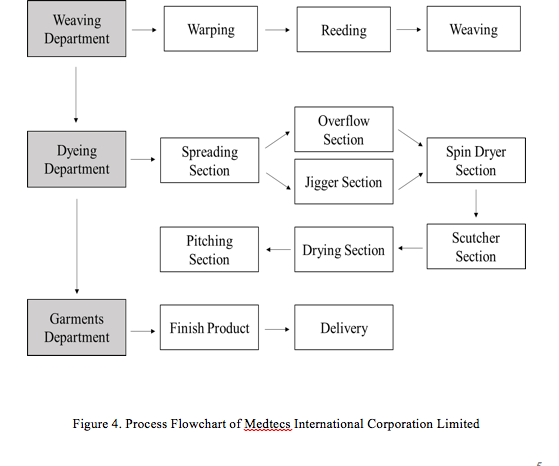

Process

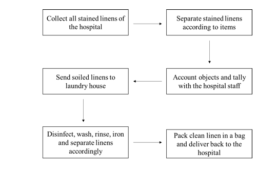

Process

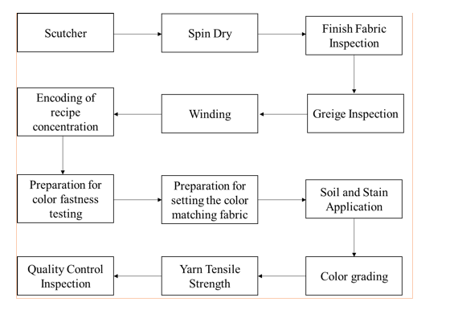

Process

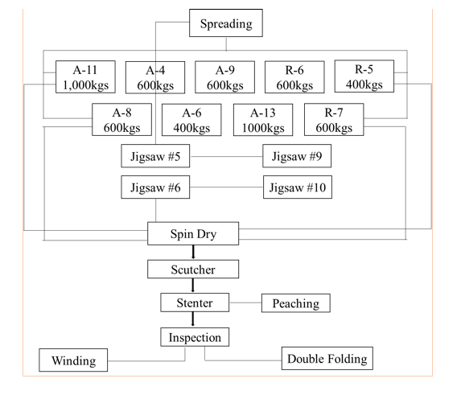

Process

Equipment

The factory has a vast space of land. There were many rolls of cloth stored there when we entered the factory. They have numerous kinds of machine in the factory. They use huge machineries and equipment. Some of the equipment that we saw there are the warping machine and the weaving machine. The warping machine is used for preparing and arranging the yarns intended for the warp of a textile material (Warping-machine, n.d). The weaving machine is a machine or loom that produces woven fabrics. In most, a device transports the weft threads and interlaces them with warp threads. In many looms, this is done by a shutde but in more modern machines other means are used such as projectiles, rapiers, and air or water jets (Science Dictionary, n.d.). They have many units of weaving machine.

They have big machines and several units of it. There was a machine were the cloth was being spread. There were machines were the cloths were dyed. They also have a separate machine for dying of cotton cloth. There was a machine where the cloth was being spin-dried. There was a long machine where the cloth is being dried.

Hierarchy of Positions

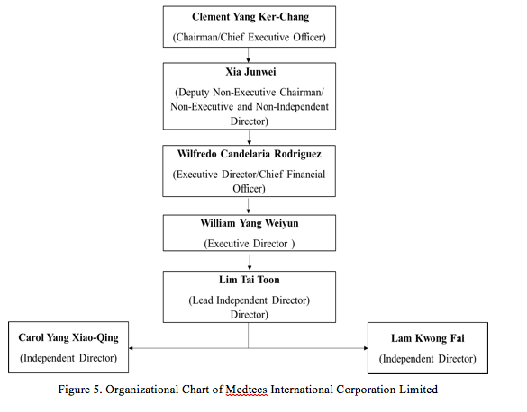

Process

Human Capital Requirements

For the laborers, they do not need to have certain qualifications because they can be trained to their assigned job. However, for the skilled workers and office workers, they need to have a background about the job. They prefer workers with work experience. As their company is manufacturing, they have many machineries. They need experienced workers to work for them.

The factory does not have a good working environment for their workers. They have a canteen inside the property of the factory. The workers has their own designated station. There were one person that operates per machine. The workers had a uniformed outfit but it was not that good. They have some safety equipment like mask and gloves but it is still not enough. It was hot inside the factory.

FCF Manufacturing Corporation

FCF Manufacturing Corporation is a leading manufacturer of high-quality fashionable bags and leather bags for export. They manufacture bags exclusively for Coach only. Their mother company is based in China. The company has been in the Free Port Area of Bataan for six years already since 2012.

The third company that we visited was the FCF Manufacturing Corporation. We were joined with another section but we were told that we would be separated in going inside the factory, as they cannot accommodate too many students at the same time. The other section went in first and we waited in the bus. When we entered the factory, it looked very organized. There were many workers. The workers were looking at us like were some foreigners visiting because it was the first time that students had toured in the factory. The factory building was very huge. We were able to see the processes on how to make Coach bags. We were able to see the designs of Coach bags that have not yet been released because they are for the next season. The price of Coach bags is really expensive.

Tapestry, Inc. was formerly known as Coach, Inc. It is an American international luxury fashion corporation established in New York City. The company is recognized for accessories and gifts for women and men, together with handbags, men’s bags, women’s and men’s small leather goods, footwear, fragrance, jewelry, outerwear, ready-to-wear, scarves, sun wear, travel accessories, and watches. Tapestry, Inc. owns three major brands: Coach, Kate Spade, and Stuart Weitzman (Wikipedia, November 18, 2017).

Value Chain

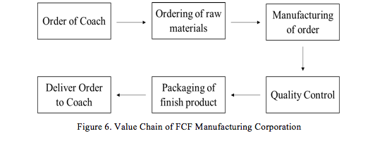

Process

Coach orders from them. They acquire the raw materials that they need from companies that Coach nominated. They manufacture the bags as per the specification of design by Coach. Once it is manufactured, they will check if it is up to the standards of Coach. If it is okay, then they deliver the bag to the designated place.

Process Flow Chart

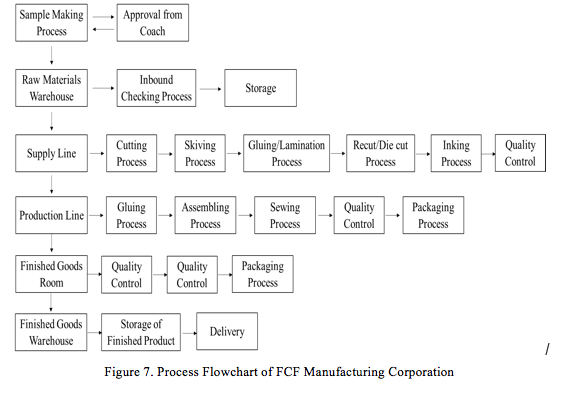

Process

Processes

Eighty percent of their supply of leather comes from Italy. They can only get materials from nominated suppliers Coach has chosen. They have various kinds of leathers in the factory. They also have other materials like fabrics, fillers and others but their materials are mostly leather which consists of about eighty percent of their materials.

It begins with the sample making process. They get approval from the Coach New York. Since their mother company is in China, they send it there. Then they will be the ones who send it Coach China. Then Coach China will send it to Coach New York for approval. Once it is approved they will start the production.

It starts in the Raw Materials Warehouse, where the leather undergoes the inbound checking process. This is the process where they check if the leather delivered to them is in accordance with the standards of Coach. After checking, it will be stored in the raw materials warehouse. In the warehouse, the temperature is set at 65 degrees below to preserve the leather and to avoid molds, as some of the leathers they use are raw. They also have fillers, which are used to make the appearance of the product better.

After that, we went to the Supply Line. This is where they make the supply for the production line. The first process is cutting. The pattern is supplied from the sample room and the pattern in the cloth is cut. They use metal molds for the machine to be able to cut the leather. Then next is the skiving process, this is used to reduce the thickness of the leather. Next is the gluing or lamination process. This is where they attach the materials that needs to be joined together. They use water-based glue. The next process is recut or die cut, where they remove excess parts of the leather. Next is the inking process, where the cut part is painted. They use the edge-painting machine to paint the cut edges of leathers. After these processes, it will be placed in what they call the supermarket where the materials are stored. The materials stored in the supermarket are used by the production line.

After that it goes to the Finished Goods Room, this is where the finished products are packaged and boxed. There finished products goes through two Quality Control checkers to ensure that the final product is really in accordance with the standards of Coach. Then it will be stored in the Finished Goods Warehouse. This is where the finished products are stored. They are placed here as they wait to be delivered to their designated places. Their products go through four hundred percent of quality control so they were really thoroughly checked so the quality is really guaranteed.

For their inventory management, they have a warehouse for raw materials. Since it is a warehouse, they inventory monthly and they put a finish inventory marking in some inventories. They have color codes for inventory. The black color represents non-moving inventory. This means that the order is already completed but there are extra wastage materials, so they just store it. Leather has a certain time when you can use it. They wait for another order or offer it to Coach. If it will not be used, the non-moving inventory can only be store up to two years and then it will be chopped into pieces before discarding it. When there are problems like when a shipment of inventory is lost, they report it to Coach. As long as the leather is not yet in the factory or lost in the factory, then they will not bear the cost.

They distribute their products to other countries Jacksonville, Japan, China, Korea, and Europe. They can only deliver or ship the finished products by a logistics company that was selected by Coach.

Equipment

The size of the factory was big. They have many equipment there. Some of the equipment that we saw there are the swing beam machine, die cut machine, edge-painting machine and the skiving machines. The swing beam machine is used for cutting the pattern in the leather. This is accompanied by a metal mold. The die cut machine is used to cut the excess parts of the fabric. The edge-painting machine is used for painting the side of the leather, which has been cut. The skiving machine slices the material off in portions, usually metal, but also leather or laminates. In leather, skiving knives trim the thickness of the leather, often around the edges, to thin the material and make it easier to work with (Wikipedia, April 14, 2016). There is also the dehumidifier, which is used to preserve the goods in the Finished Goods Warehouse. There is one in each bay of boxes.

The maintenance of the machines are done every day but they have general maintenance of machines weekly. They have spare machines in case a machine is damaged.

Human Capital Requirements

They stick with the Labor Code. The allowable overtime is four hours so the maximum hours that the worker would be in the factory is 12 hours. They provide the workers something to block the noise because the noise can affect their hearing especially they work for long hours. It is one of the standard operating procedure of Coach. The workers have two breaks, lunch break and snack break.

The factory has a huge space of property. They have a nice working environment for their employees. This is the most decent company among all the companies that we had visited. They have many employees. They said that they have currently about 1,003 man power. They have forty-eight production lines. They have a training center for new workers. They produce about 250,000 to 300,000 units of bag per month. We saw workers sleeping because when we toured around the factory it was already their break time.

Dunlop International (Philippines), Inc.

The company has been in the Free Port Area of Bataan for forty years already. It was established in the Philippines on May 1977. It was formerly known as Dunlop Slazenger (Phils) Inc. but a Japanese bought the company and the company name was changed. It was formerly a British-owned company based in England. They manufacture tennis balls and squash balls for export (Job Street, n.d.). Dunlop is a huge multinational company so we can be sure that the products that they produce are excellent in quality. Dunlop is a famous brand in the sports world. Their tennis ball is the most famous brand of tennis ball. It is the one being used in international tournaments. Dunlop Sport is a British sporting goods company that focusses in tennis and golf equipment. Dunlop have been making sporting equipment since 1910. Dunlop Sport is the present supplier for the ATP World Team Championship in Düsseldorf. (Wikepedia, November 2, 2017).

This is the last company that we had visited. We went here on our last day in Bataan. We waited for a while in our bus because their security is very tight. We were not allowed to take pictures inside the factory. Before entering the factory, we were told to from two lines and we were given facemasks. As their production has chemicals and rubber as raw materials, the smell is not good. It was hot inside the factory. They had a huge factory plant. There were many workers. They were fully equipped with safety equipment unlike the other manufacturing companies that we had visited. They had an organized factory. There were signs on what process is being that in the certain part in the factory. It was loud inside the factory because of the machines so we had a hard time hearing what the speaker was saying. They had many units and various kinds of machineries and equipment in the factory.

Value Chain

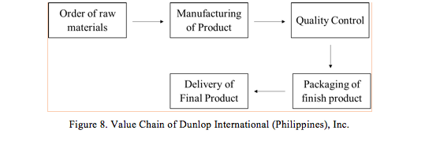

Process

It starts with the ordering of materials to be used in production. Then the product is manufactured. Once the product is manufactured, it is checked if the quality is in accordance with their standards. If the quality is good, it will be packed. Then the final product is ready to be delivered.

Processes

The company acquires their raw material from abroad. Sheep cloth is not available in the country and there is a designated supplier assigned to them by the main company for their raw materials. They use rubber and various kinds of chemicals in their production.

The first process is the chemical weighing process, they weigh the chemical to be used in production. Then next is the rubber weighing process, they weigh the rubber to be used in production. Next is the compounding or mixing process, this is where they mix the materials together. There is the initial mixing and the final mixing. In the final mixing sulfur is added in the mixture. The next process is extrusion, this is where the mixture is divided into smaller portions called pellets. It will be placed in the forming machine with specific pressure and time and form sheets will be made. Next is the deflashing process, this is where they remove the excess parts and will be placed in the conveyor. The outcome is the deep cups, the edges will be grinded, and adhesive will be applied. The next is the core molding process, this is where the core of the tennis ball is polished. The surface will be grinded and will be applied with adhesive.

For the cloth preparation, the first process is spreading. The cloth that they use are from abroad and it is a sheep cloth. They put adhesive in the back of the cloth. They have two colors of cloth, which is orange and green. The orange one is for kids and beginners because it is not that hard so when they are hit by the ball it will be less painful than the green one. Then next is the cloth clicking process, they use dumbbells and the cloth is cut into shape. Next is the cloth dipping process, wherein the cloth is brush coated.

Once the core and the cloth is ready, it undergoes the covering process, where the cloth and the core meets. The cloth, which is the exterior of the tennis ball, will be attached to the surface of the core. Next is the final curing process, where the adhesive is cooked so it will be dry and the cloth will surely be glued with the core. The next process is steam and dry, where the ball is steamed to make the cloth fluffy again. Afterwards it will go to the finishing section, where it is trimmed, inspected, and the brand is stamped on the tennis ball. After that is the canning process, where it will be placed in a can. They put pressure inside the can to maintain the pressure of the tennis ball. Then they put sleeves to the can, where their brand is displayed. Then it will be placed in a box and stored. After all of these processes, it is ready to be shipped to other places. They have a tournament room, where the tennis balls are tested. The tennis balls will be used for International Tennis tournaments.

Equipment

They have a huge factory. Upon entering, we saw numerous units of different kinds of machine. Some of the equipment that we saw there are the forming machine, deflashing machine, and conveyor. The forming machine is used to make the form sheets. There is a specific pressure and time. The deflasing machine is used to remove the excess parts of the core of the ball. The conveyor is a machine that provides industrialized movement of materials in a factory.

```
They have maintenance for their machineries and equipment every day.
```

Human Capital Requirements

Dunlop is an international company so they really screen the people that would apply job in their company. They would be strict on the requiremnts for office and skilled workers. For laborers, there is not much qualification. However, for office and skilled workers they need to have a background about the work and certain qualifications that the company specifies. They prefer workers with experience.

Process Flow Chart

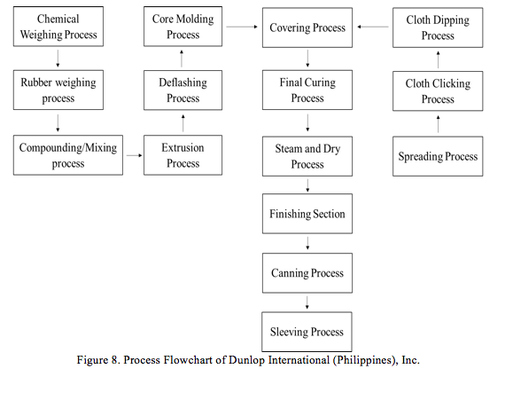

Process

Bibliography: Retrieved from https://medtecs-ph.com/About-Us/ Retrieved from https://medtecs-ph.com/Products/ Wikipedia. (2017, June 13). Bending machine (manufacturing). Retrieved from https://en.wikipedia.org/wiki/Bending_machine_(manufacturing) Cano, M. (March 16). What is a welding machine? Retrieved from https://www.quora.com/What-is-a-welding-machine Khemani, H. (2009, November 13). What is the CNC machine? How CNC machine works? Retrieved from http://www.brighthubengineering.com/manufacturing-technology/55787- what-is-the-cnc-machine-how-cnc-machine-works/ Wikipedia. (2016, April 14). Skiving machine. Retrieved from https://en.wikipedia.org/wiki/Skiving_machine Wikipedia. (n.d.). Skiving (leathercraft). Retrieved from https://en.wikipedia.org/wiki/Skiving_(leathercraft) Wikipedia. (2017, November 17). Weaving. Retrieved from https://en.wikipedia.org/wiki/Weaving Wikipedia. (2017, September 18). Dyeing. Retrieved from https://en.wikipedia.org/wiki/Dyeing Warping-machine. (n.d.). Retrieved from https://www.wordnik.com/words/warping-machine Science Dictionary. (n.d.). What is weaving machine? Retrieved from http://thesciencedictionary.org/weaving-machine/ Encyclopædia Britannica. (n.d.). Conveyor. Retrieved from https://www.britannica.com/technology/conveyor Rappler. (2012, May 28). Made in the Philippines: more Coach bags. Retrieved from https://www.rappler.com/business/6018-made-in-the-philippines-more-coach-bags Job Street. (n.d.). Dunlop International (Philippines), Inc. Retrieved from https://www.jobstreet.com.ph/en/companies/493686-dunlop-international-philippines-inc Job Street. (n.d.). FCF Manufacturing Corporation. Retrieved rom https://www.jobstreet.com.ph/en/companies/987396-fcf-manufacturing-corporation Wikipedia. (2017, November 18). Tapestry, Inc. retrieved from https://en.wikipedia.org/wiki/Tapestry,_Inc. Wikipedia. (2017, November 2). Dunlop Sport. Retrieved from https://en.wikipedia.org/wiki/Dunlop_Sport Investor relations. (n.d.). Retrieved from http://www.tapestry.com/investors/ Davies, K. (n.d.). The full history of Coach handbags. Retrieved from http://handbags.lovetoknow.com/The_Full_History_of_Coach_Handbags The Bag Molding Process. (n.d.). Retrieved from https://www.thomasnet.com/articles/custom- manufacturing-fabricating/bag-molding-process/ Retrieved from http://www.referenceforbusiness.com/history2/18/Coach-Inc.html